# Act Report

### Introduction

I will be exploring these variables and the associations between them to answer the following research questions

- RQ1. What source has the highest number of tweets?
- RQ2. Does a particular dog stage have higher tweets?
- RQ3. What is the top rating?
- RQ4. Is there a correlation between ratings and dog stage?
- RQ5. Is there a correlation between ratings and source?

#### Research Question 1: What source has the highest number of tweets?

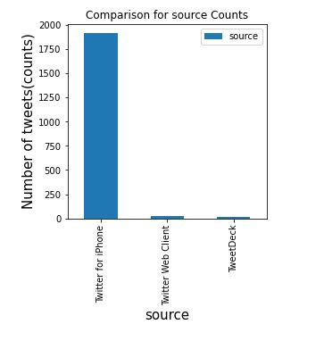

##### Conclusion

We can see from both our analysis and visualization that the source with the highest number of tweets is Twitter for iphone with 1915 tweets out of 1954 tweets

#### Research Question 2: Does a particular dog stage have higher tweets?

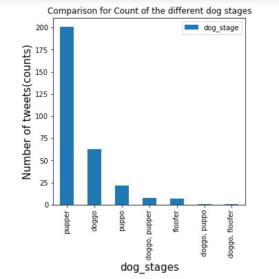

##### Conclusion

We can see from both our analysis and visualization that pupper dog_stage has the highest number of tweets with 201 tweets out of 303 tweets, followed by doggo and puppo with 63 and 22 respectively

#### Research Question 3: What is the top rating?

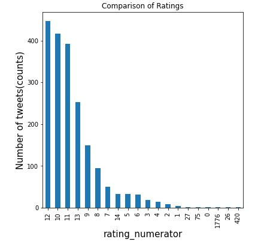

##### Conclusion

We can see from both our analysis and visualization that the the top rating is 12/10 with 446 tweets, followed closely by 10/10 and 11/10

#### Research Question 4: Is there a correlation between ratings and dog stage?

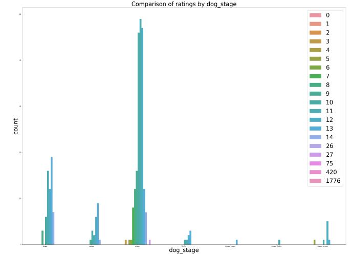

#### Research Question 5: Is there a correlation between ratings and source?

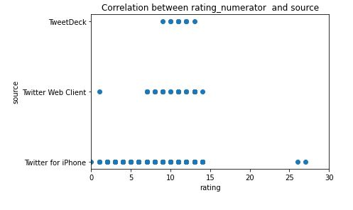

##### Conclusion

We can see from both our analysis and visualization that the there is no correlation between ratings and source. This implies that the tweet source does not influence the rating of the dog